# Chapter3. Pandas数据分析

pandas作为数据分析的首选库，经常与其它工具一起使用，比如数值计算工具NumPy和SciPy，分析库statsmodels和scikit-learn，以及数据可视化库matplotlib和plotly。pandas是基于NumPy数组构建的，特别是基于数组的函数和不使用for循环的数据处理。

虽然pandas采用大量的NumPy编码风格，但两者最大的不同是pandas专门为处理表格和混杂数据设计的，而NumPy更适合处理统一的数值数组数据。

```python
# 导入numpy和pandas
import pandas as pd
import numpy as np
```

## 3.1 pandas数据结构

### 3.1.1 Series

类似于一维数组的对象，包含一个**值序列**（可以是Python序列、数组或标量值等）以及与之相关的数据标签，称为**索引index**。

#### ① 创建Series

创建Series的方法：`pd.Series(data, index=index)`

```python
# 1. data是数组
import numpy as np
s = pd.Series(np.random.randn(5))
s  # 索引在左边（默认从0至N-1），值在右边
```

```
0   -0.744647
1   -0.040966
2    0.183407
3   -0.320274
4    0.631586
dtype: float64
```

```python
s = pd.Series(np.random.randn(5),index=['a','b','c','d','e'])  # 自定义索引，需与data长度一致
# s = pd.Series(np.random.randn(5),index=list('abcde'))
s
```

```
a   -0.361261
b   -0.642157
c    0.161086
d    1.485567
e   -0.621713
dtype: float64
```

```python
# index属性：获取Series对象的索引
s.index
```

```
Index(['a', 'b', 'c', 'd', 'e'], dtype='object')
```

```python
# values属性：获取Series对象的值，返回数组
s.values
```

```
array([-0.36126093, -0.64215705,  0.16108552,  1.4855672 , -0.62171346])
```

```python
# 2. data是字典dict：因为Series是索引到数据的一个映射，因此可以将其看成是定长的有序字典
data = {'b':17,'a':60,'d':7,'c':21}
pd.Series(data)  # Series的索引就是原字典的键（有序排列）
```

```
b    17
a    60
d     7
c    21
dtype: int64
```

```python
index = ['a','b','c','d','e']  # 将字典的键按照指定顺序排列
pd.Series(data,index=index)  # pandas中用NaN标志缺失值
```

```
a    60.0
b    17.0
c    21.0
d     7.0
e     NaN
dtype: float64
```

#### ② ndarray-like

Series与ndarray有很多相似操作，可以使用NumPy函数或类似NumPy的运算，仍然保留索引值的链接

```python
# 索引与切片
s[0]  # by position（索引位置）
```

```
-0.36126092779751084
```

```python
s[1:3]  # 根据position切片
```

```
b   -0.642157
c    0.161086
dtype: float64
```

```python
s['a']  # by label（索引值）
```

```
-0.36126092779751084
```

```python
s['a':'c']  # 根据label切片，两端值都包含在内
```

```
a   -0.361261
b   -0.642157
c    0.161086
dtype: float64
```

```python
s[['a','c']]  # 对于不连续的label，需要传入列表
```

```
a   -0.361261
c    0.161086
dtype: float64
```

```python
s[s > s.median()]  # 布尔索引
```

```
c    0.161086
d    1.485567
dtype: float64
```

```python
# 类似NumPy的运算
s * 2
```

```
a   -0.722522
b   -1.284314
c    0.322171
d    2.971134
e   -1.243427
dtype: float64
```

```python
# 使用NumPy函数
np.square(s)
```

```
a    0.130509
b    0.412366
c    0.025949
d    2.206910
e    0.386528
dtype: float64
```

### 3.1.2 DataFrame

DataFrame既有行索引又有列索引，是一个表格型的数据结构，包含已排序的列集合，每一列可以是不同的值类型（数值、字符串、布尔值等）。

#### ① 创建DataFrame

创建DataFrame的方法：`pd.DataFrame(data, index=index, columns=columns)`

```python
# 1. data是二维数组
data = np.random.randn(8,3)
data
```

```
array([[-1.0015299 , -1.67418181,  0.62129522],
       [ 0.29998214, -0.08618301,  2.22500262],
       [-0.38979434,  0.97520376,  0.16705551],
       [-0.32746294, -0.52065483, -0.35203353],
       [ 0.25662599,  0.79594319, -0.22096199],
       [ 0.02054113, -0.42127725, -0.47613606],
       [ 0.40860163, -0.8841146 ,  0.03543155],
       [ 1.01772467, -0.3589825 , -1.4258324 ]])
```

```python
# 使用pd.DataFrame创建DataFrame
pd.DataFrame(data)  # Jupyter notebook中的DataFrame对象会以友好的HTML表格的方式呈现
```

|  | 0 | 1 | 2 |
| --- | --- | --- | --- |
| 0 | -1.001530 | -1.674182 | 0.621295 |
| 1 | 0.299982 | -0.086183 | 2.225003 |
| 2 | -0.389794 | 0.975204 | 0.167056 |
| 3 | -0.327463 | -0.520655 | -0.352034 |
| 4 | 0.256626 | 0.795943 | -0.220962 |
| 5 | 0.020541 | -0.421277 | -0.476136 |
| 6 | 0.408602 | -0.884115 | 0.035432 |
| 7 | 1.017725 | -0.358982 | -1.425832 |

```python
# 传递index（row labels）参数，指定行索引
dates = pd.date_range('20221001',periods=data.shape[0])
pd.DataFrame(data, index=dates)
```

|  | 0 | 1 | 2 |
| --- | --- | --- | --- |
| 2022-10-01 | -1.001530 | -1.674182 | 0.621295 |
| 2022-10-02 | 0.299982 | -0.086183 | 2.225003 |
| 2022-10-03 | -0.389794 | 0.975204 | 0.167056 |
| 2022-10-04 | -0.327463 | -0.520655 | -0.352034 |
| 2022-10-05 | 0.256626 | 0.795943 | -0.220962 |
| 2022-10-06 | 0.020541 | -0.421277 | -0.476136 |
| 2022-10-07 | 0.408602 | -0.884115 | 0.035432 |
| 2022-10-08 | 1.017725 | -0.358982 | -1.425832 |

```python
# 传递columns（column labels）参数，指定列索引
df = pd.DataFrame(data, index=dates, columns=['A','B','C'])
df  # 将DataFrame对象传递给参数df并查看
```

|  | A | B | C |
| --- | --- | --- | --- |
| 2022-10-01 | -1.001530 | -1.674182 | 0.621295 |
| 2022-10-02 | 0.299982 | -0.086183 | 2.225003 |
| 2022-10-03 | -0.389794 | 0.975204 | 0.167056 |
| 2022-10-04 | -0.327463 | -0.520655 | -0.352034 |
| 2022-10-05 | 0.256626 | 0.795943 | -0.220962 |
| 2022-10-06 | 0.020541 | -0.421277 | -0.476136 |
| 2022-10-07 | 0.408602 | -0.884115 | 0.035432 |
| 2022-10-08 | 1.017725 | -0.358982 | -1.425832 |

```python
# shape属性：获取DataFrame的行数和列数
df.shape
```

```
(8, 3)
```

```python
# index属性：获取DataFrame的行索引
df.index
```

```
DatetimeIndex(['2022-10-01', '2022-10-02', '2022-10-03', '2022-10-04',
               '2022-10-05', '2022-10-06', '2022-10-07', '2022-10-08'],
              dtype='datetime64[ns]', freq='D')
```

```python
# columns属性：获取DataFrame的列索引
df.columns
```

```
Index(['A', 'B', 'C'], dtype='object')
```

```python
# values属性：获取DataFrame的值，返回数组
df.values
```

```
array([[-1.0015299 , -1.67418181,  0.62129522],
       [ 0.29998214, -0.08618301,  2.22500262],
       [-0.38979434,  0.97520376,  0.16705551],
       [-0.32746294, -0.52065483, -0.35203353],
       [ 0.25662599,  0.79594319, -0.22096199],
       [ 0.02054113, -0.42127725, -0.47613606],
       [ 0.40860163, -0.8841146 ,  0.03543155],
       [ 1.01772467, -0.3589825 , -1.4258324 ]])
```

```python
# 2.data是由Series组成的字典，字典的键作为列索引。
data2 = {'one':pd.Series([1.,2.,3.],index=['a','b','c']),
         'two':pd.Series([4.,5.,6.,7.],index=['a','b','c','d'])}
pd.DataFrame(data2)
```

|  | one | two |
| --- | --- | --- |
| a | 1.0 | 4.0 |
| b | 2.0 | 5.0 |
| c | 3.0 | 6.0 |
| d | NaN | 7.0 |

```python
# 指定行序列
pd.DataFrame(data2,index=['d','b','a'])
```

|  | one | two |
| --- | --- | --- |
| d | NaN | 7.0 |
| b | 2.0 | 5.0 |
| a | 1.0 | 4.0 |

```python
# 指定列序列
pd.DataFrame(data2,index=['d','b','a'],columns=['two','three'])
# 传入的列在数据中找不到，会在结果中产生缺失值NaN
```

|  | two | three |
| --- | --- | --- |
| d | 7.0 | NaN |
| b | 5.0 | NaN |
| a | 4.0 | NaN |

```python
# 3. data是由列表list或数组array组成的字典，字典的键作为列索引。
data3 = {'state':['Ohio','Ohio','Ohio','Nevada','Nevada','Nevada'],
         'year':[2000,2001,2002,2000,2001,2002],
         'population':np.random.random(6)}
df3 = pd.DataFrame(data3)
df3
```

|  | state | year | population |
| --- | --- | --- | --- |
| 0 | Ohio | 2000 | 0.574235 |
| 1 | Ohio | 2001 | 0.422707 |
| 2 | Ohio | 2002 | 0.838100 |
| 3 | Nevada | 2000 | 0.981511 |
| 4 | Nevada | 2001 | 0.386422 |
| 5 | Nevada | 2002 | 0.321994 |

#### ② 列操作

```python
# 获取列值
df3['state']  # 该写法适用于任意列
```

```
0      Ohio
1      Ohio
2      Ohio
3    Nevada
4    Nevada
5    Nevada
Name: state, dtype: object
```

```python
df3.population  # 该写法只有在列名是有效的变量名时有效，可使用tab补全
```

```
0    0.574235
1    0.422707
2    0.838100
3    0.981511
4    0.386422
5    0.321994
Name: population, dtype: float64
```

```python
# 修改列值
df3['area'] = 16.5  # 将数值赋值给一个列
df3
```

|  | state | year | population | area |
| --- | --- | --- | --- | --- |
| 0 | Ohio | 2000 | 0.574235 | 16.5 |
| 1 | Ohio | 2001 | 0.422707 | 16.5 |
| 2 | Ohio | 2002 | 0.838100 | 16.5 |
| 3 | Nevada | 2000 | 0.981511 | 16.5 |
| 4 | Nevada | 2001 | 0.386422 | 16.5 |
| 5 | Nevada | 2002 | 0.321994 | 16.5 |

```python
df3['multiple'] = df3['population'] * df3['area']  # 将计算字段赋值给一个列
df3
```

|  | state | year | population | area | multiple |
| --- | --- | --- | --- | --- | --- |
| 0 | Ohio | 2000 | 0.574235 | 16.5 | 9.474869 |
| 1 | Ohio | 2001 | 0.422707 | 16.5 | 6.974665 |
| 2 | Ohio | 2002 | 0.838100 | 16.5 | 13.828654 |
| 3 | Nevada | 2000 | 0.981511 | 16.5 | 16.194939 |
| 4 | Nevada | 2001 | 0.386422 | 16.5 | 6.375970 |
| 5 | Nevada | 2002 | 0.321994 | 16.5 | 5.312904 |

```python
df3['bools'] = df3['state']=='Ohio'  # 将布尔值赋值给一个列
df3
```

|  | state | year | population | area | multiple | bools |
| --- | --- | --- | --- | --- | --- | --- |
| 0 | Ohio | 2000 | 0.574235 | 16.5 | 9.474869 | True |
| 1 | Ohio | 2001 | 0.422707 | 16.5 | 6.974665 | True |
| 2 | Ohio | 2002 | 0.838100 | 16.5 | 13.828654 | True |
| 3 | Nevada | 2000 | 0.981511 | 16.5 | 16.194939 | False |
| 4 | Nevada | 2001 | 0.386422 | 16.5 | 6.375970 | False |
| 5 | Nevada | 2002 | 0.321994 | 16.5 | 5.312904 | False |

```python
s = pd.Series([16.5,18.9],index=[0,3])
df3['area'] = s  # 将Series对象赋值给一个列，精确匹配行索引
df3
```

|  | state | year | population | area | multiple | bools |
| --- | --- | --- | --- | --- | --- | --- |
| 0 | Ohio | 2000 | 0.574235 | 16.5 | 9.474869 | True |
| 1 | Ohio | 2001 | 0.422707 | NaN | 6.974665 | True |
| 2 | Ohio | 2002 | 0.838100 | NaN | 13.828654 | True |
| 3 | Nevada | 2000 | 0.981511 | 18.9 | 16.194939 | False |
| 4 | Nevada | 2001 | 0.386422 | NaN | 6.375970 | False |
| 5 | Nevada | 2002 | 0.321994 | NaN | 5.312904 | False |

```python
df3['area'] = np.arange(6.)  # 将列表或数组赋值给一个列，长度必须匹配
df3
```

|  | state | year | population | area | multiple | bools |
| --- | --- | --- | --- | --- | --- | --- |
| 0 | Ohio | 2000 | 0.574235 | 0.0 | 9.474869 | True |
| 1 | Ohio | 2001 | 0.422707 | 1.0 | 6.974665 | True |
| 2 | Ohio | 2002 | 0.838100 | 2.0 | 13.828654 | True |
| 3 | Nevada | 2000 | 0.981511 | 3.0 | 16.194939 | False |
| 4 | Nevada | 2001 | 0.386422 | 4.0 | 6.375970 | False |
| 5 | Nevada | 2002 | 0.321994 | 5.0 | 5.312904 | False |

```python
# 移除列
del df3['bools']
df3
```

|  | state | year | population | area | multiple |
| --- | --- | --- | --- | --- | --- |
| 0 | Ohio | 2000 | 0.574235 | 0.0 | 9.474869 |
| 1 | Ohio | 2001 | 0.422707 | 1.0 | 6.974665 |
| 2 | Ohio | 2002 | 0.838100 | 2.0 | 13.828654 |
| 3 | Nevada | 2000 | 0.981511 | 3.0 | 16.194939 |
| 4 | Nevada | 2001 | 0.386422 | 4.0 | 6.375970 |
| 5 | Nevada | 2002 | 0.321994 | 5.0 | 5.312904 |

```python
# 创建两个列Sum1和Sum2，分别是area+multiple和area+Sum1
# 方法1：使用列操作，会更改原始数据
df4 = df3.copy()
df4['Sum1']=df4['area']+df4['multiple']
df4['Sum2']=df4['area']+df4['Sum1']
df4
```

|  | state | year | population | area | multiple | Sum1 | Sum2 |
| --- | --- | --- | --- | --- | --- | --- | --- |
| 0 | Ohio | 2000 | 0.574235 | 0.0 | 9.474869 | 9.474869 | 9.474869 |
| 1 | Ohio | 2001 | 0.422707 | 1.0 | 6.974665 | 7.974665 | 8.974665 |
| 2 | Ohio | 2002 | 0.838100 | 2.0 | 13.828654 | 15.828654 | 17.828654 |
| 3 | Nevada | 2000 | 0.981511 | 3.0 | 16.194939 | 19.194939 | 22.194939 |
| 4 | Nevada | 2001 | 0.386422 | 4.0 | 6.375970 | 10.375970 | 14.375970 |
| 5 | Nevada | 2002 | 0.321994 | 5.0 | 5.312904 | 10.312904 | 15.312904 |

```python
# 方法2：使用assign()：基于现有列轻松创建一个新的列，并且返回数据的副本而不影响原始数据
df3.assign( Sum1 = lambda x:x['area'] + x['multiple'],
            Sum2 = lambda x:x['area'] + x['Sum1'])
```

|  | state | year | population | area | multiple | Sum1 | Sum2 |
| --- | --- | --- | --- | --- | --- | --- | --- |
| 0 | Ohio | 2000 | 0.574235 | 0.0 | 9.474869 | 9.474869 | 9.474869 |
| 1 | Ohio | 2001 | 0.422707 | 1.0 | 6.974665 | 7.974665 | 8.974665 |
| 2 | Ohio | 2002 | 0.838100 | 2.0 | 13.828654 | 15.828654 | 17.828654 |
| 3 | Nevada | 2000 | 0.981511 | 3.0 | 16.194939 | 19.194939 | 22.194939 |
| 4 | Nevada | 2001 | 0.386422 | 4.0 | 6.375970 | 10.375970 | 14.375970 |
| 5 | Nevada | 2002 | 0.321994 | 5.0 | 5.312904 | 10.312904 | 15.312904 |

```python
df3
```

|  | state | year | population | area | multiple |
| --- | --- | --- | --- | --- | --- |
| 0 | Ohio | 2000 | 0.574235 | 0.0 | 9.474869 |
| 1 | Ohio | 2001 | 0.422707 | 1.0 | 6.974665 |
| 2 | Ohio | 2002 | 0.838100 | 2.0 | 13.828654 |
| 3 | Nevada | 2000 | 0.981511 | 3.0 | 16.194939 |
| 4 | Nevada | 2001 | 0.386422 | 4.0 | 6.375970 |
| 5 | Nevada | 2002 | 0.321994 | 5.0 | 5.312904 |

#### ③ 索引与切片

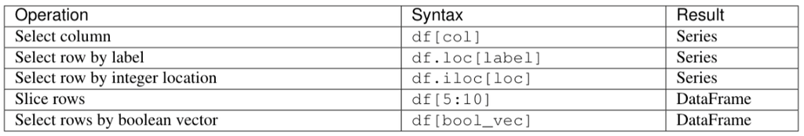

##### A. Seleting column or row only

```python
# Select column 选择列
df['A']  # 等同于df.A
```

```
2022-10-01   -1.001530
2022-10-02    0.299982
2022-10-03   -0.389794
2022-10-04   -0.327463
2022-10-05    0.256626
2022-10-06    0.020541
2022-10-07    0.408602
2022-10-08    1.017725
Freq: D, Name: A, dtype: float64
```

```python
df[['A','C']]  # 传入列表
```

|  | A | C |
| --- | --- | --- |
| 2022-10-01 | -1.001530 | 0.621295 |
| 2022-10-02 | 0.299982 | 2.225003 |
| 2022-10-03 | -0.389794 | 0.167056 |
| 2022-10-04 | -0.327463 | -0.352034 |
| 2022-10-05 | 0.256626 | -0.220962 |
| 2022-10-06 | 0.020541 | -0.476136 |
| 2022-10-07 | 0.408602 | 0.035432 |
| 2022-10-08 | 1.017725 | -1.425832 |

```python
# slice rows 对行进行切片
df[:3]  # by position
```

|  | A | B | C |
| --- | --- | --- | --- |
| 2022-10-01 | -1.001530 | -1.674182 | 0.621295 |
| 2022-10-02 | 0.299982 | -0.086183 | 2.225003 |
| 2022-10-03 | -0.389794 | 0.975204 | 0.167056 |

```python
df['20221003':'20221007']  # by label
```

|  | A | B | C |
| --- | --- | --- | --- |
| 2022-10-03 | -0.389794 | 0.975204 | 0.167056 |
| 2022-10-04 | -0.327463 | -0.520655 | -0.352034 |
| 2022-10-05 | 0.256626 | 0.795943 | -0.220962 |
| 2022-10-06 | 0.020541 | -0.421277 | -0.476136 |
| 2022-10-07 | 0.408602 | -0.884115 | 0.035432 |

##### B. Selection by Label: `.loc`

```python
df.loc['20221001':'20221005',['A','C']] # 根据label切片，两端值都包含在内
```

|  | A | C |
| --- | --- | --- |
| 2022-10-01 | -1.001530 | 0.621295 |
| 2022-10-02 | 0.299982 | 2.225003 |
| 2022-10-03 | -0.389794 | 0.167056 |
| 2022-10-04 | -0.327463 | -0.352034 |
| 2022-10-05 | 0.256626 | -0.220962 |

```python
df.loc['20221001',['A','C']]
```

```
A   -1.001530
C    0.621295
Name: 2022-10-01 00:00:00, dtype: float64
```

```python
df.loc[:,'A']
```

```
2022-10-01   -1.001530
2022-10-02    0.299982
2022-10-03   -0.389794
2022-10-04   -0.327463
2022-10-05    0.256626
2022-10-06    0.020541
2022-10-07    0.408602
2022-10-08    1.017725
Freq: D, Name: A, dtype: float64
```

```python
df.loc[dates[0],'A']
```

```
-1.0015299021486688
```

```python
df.at[dates[0],'A']  # 等同于上一写法
```

```
-1.0015299021486688
```

##### C. Selection by position: `.iloc`

```python
df.iloc[3:5,0:2]  # 根据integer location进行切片，前闭后开
```

|  | A | B |
| --- | --- | --- |
| 2022-10-04 | -0.327463 | -0.520655 |
| 2022-10-05 | 0.256626 | 0.795943 |

```python
df.iloc[[1,2,4],[0,2]]
```

|  | A | C |
| --- | --- | --- |
| 2022-10-02 | 0.299982 | 2.225003 |
| 2022-10-03 | -0.389794 | 0.167056 |
| 2022-10-05 | 0.256626 | -0.220962 |

```python
df.iloc[3]
```

```
A   -0.327463
B   -0.520655
C   -0.352034
Name: 2022-10-04 00:00:00, dtype: float64
```

```python
df.iloc[:3,:]
```

|  | A | B | C |
| --- | --- | --- | --- |
| 2022-10-01 | -1.001530 | -1.674182 | 0.621295 |
| 2022-10-02 | 0.299982 | -0.086183 | 2.225003 |
| 2022-10-03 | -0.389794 | 0.975204 | 0.167056 |

```python
df.iloc[:,2]
```

```
2022-10-01    0.621295
2022-10-02    2.225003
2022-10-03    0.167056
2022-10-04   -0.352034
2022-10-05   -0.220962
2022-10-06   -0.476136
2022-10-07    0.035432
2022-10-08   -1.425832
Freq: D, Name: C, dtype: float64
```

```python
df.iloc[1,1]
```

```
-0.0861830116047846
```

```python
df.iat[1,1]  # 等同于上一写法
```

```
-0.0861830116047846
```

##### D. Boolean indexing

```python
df[df > 0]
```

|  | A | B | C |
| --- | --- | --- | --- |
| 2022-10-01 | NaN | NaN | 0.621295 |
| 2022-10-02 | 0.299982 | NaN | 2.225003 |
| 2022-10-03 | NaN | 0.975204 | 0.167056 |
| 2022-10-04 | NaN | NaN | NaN |
| 2022-10-05 | 0.256626 | 0.795943 | NaN |
| 2022-10-06 | 0.020541 | NaN | NaN |
| 2022-10-07 | 0.408602 | NaN | 0.035432 |
| 2022-10-08 | 1.017725 | NaN | NaN |

```python
df[df['A'] > 0]
```

|  | A | B | C |
| --- | --- | --- | --- |
| 2022-10-02 | 0.299982 | -0.086183 | 2.225003 |
| 2022-10-05 | 0.256626 | 0.795943 | -0.220962 |
| 2022-10-06 | 0.020541 | -0.421277 | -0.476136 |
| 2022-10-07 | 0.408602 | -0.884115 | 0.035432 |
| 2022-10-08 | 1.017725 | -0.358982 | -1.425832 |

```python
df[(df['A']>0) & (df['A']<1)]
```

|  | A | B | C |
| --- | --- | --- | --- |
| 2022-10-02 | 0.299982 | -0.086183 | 2.225003 |
| 2022-10-05 | 0.256626 | 0.795943 | -0.220962 |
| 2022-10-06 | 0.020541 | -0.421277 | -0.476136 |
| 2022-10-07 | 0.408602 | -0.884115 | 0.035432 |

```python
# isin()
df2 = df.copy()
df2['D'] = ['one','one','two','three','four','three',np.nan, np.nan]
df2[df2['D'].isin(['two','four'])]
```

|  | A | B | C | D |
| --- | --- | --- | --- | --- |
| 2022-10-03 | -0.389794 | 0.975204 | 0.167056 | two |
| 2022-10-05 | 0.256626 | 0.795943 | -0.220962 | four |

## 3.2 基本功能

```python
import numpy as np
import pandas as pd
s = pd.Series(np.random.randn(5),index=['a','b','c','d','e'])
s
```

```
a   -0.187045
b   -0.058067
c    0.616631
d    1.010504
e    1.798750
dtype: float64
```

```python
data = np.random.randn(8,3)
dates = pd.date_range('20221001',periods=8)
df = pd.DataFrame(data, index=dates, columns=['A','B','C'])
df
```

|  | A | B | C |
| --- | --- | --- | --- |
| 2022-10-01 | -0.108899 | 0.962418 | 0.462161 |
| 2022-10-02 | 0.926922 | -1.200499 | -0.112129 |
| 2022-10-03 | -0.581398 | -1.726547 | -0.375088 |
| 2022-10-04 | 3.024233 | 0.360516 | -0.706446 |
| 2022-10-05 | -0.376288 | -0.155509 | 1.841796 |
| 2022-10-06 | 0.034091 | -0.552255 | -0.262247 |
| 2022-10-07 | 0.541646 | -0.603060 | 0.204446 |
| 2022-10-08 | -1.570842 | -0.004045 | 0.271995 |

### 3.2.1 Viewing data 查看数据

#### ① 查看头尾数据

`head()` 和 `tail()`方法可查看pandas对象的头尾数据，默认为5，可传递参数

```python
s1 = pd.Series(np.random.randn(1000))
s1.head()
```

```
0   -0.753850
1   -1.185251
2   -0.135049
3    0.502739
4   -0.027365
dtype: float64
```

```python
s1.tail()
```

```
995    0.271654
996    0.454254
997    0.016627
998    0.653548
999    0.725737
dtype: float64
```

```python
df.head()
```

|  | A | B | C |
| --- | --- | --- | --- |
| 2022-10-01 | -0.108899 | 0.962418 | 0.462161 |
| 2022-10-02 | 0.926922 | -1.200499 | -0.112129 |
| 2022-10-03 | -0.581398 | -1.726547 | -0.375088 |
| 2022-10-04 | 3.024233 | 0.360516 | -0.706446 |
| 2022-10-05 | -0.376288 | -0.155509 | 1.841796 |

```python
df.tail(3)
```

|  | A | B | C |
| --- | --- | --- | --- |
| 2022-10-06 | 0.034091 | -0.552255 | -0.262247 |
| 2022-10-07 | 0.541646 | -0.603060 | 0.204446 |
| 2022-10-08 | -1.570842 | -0.004045 | 0.271995 |

#### ② 查看信息

`info()`方法可以查看DataFrame对象的索引、列的数据类型等信息。

```python
df.info()
```

```
<class 'pandas.core.frame.DataFrame'>
DatetimeIndex: 8 entries, 2022-10-01 to 2022-10-08
Freq: D
Data columns (total 3 columns):
 #   Column  Non-Null Count  Dtype
---  ------  --------------  -----
 0   A       8 non-null      float64
 1   B       8 non-null      float64
 2   C       8 non-null      float64
dtypes: float64(3)
memory usage: 256.0 bytes
```

#### ③ 创建副本

`copy()`方法可以创建pandas对象的副本并返回一个新的对象。一般来说，大部分的操作和方法都会返回一个新的对象，而不会影响到初始对象，因此不太需要用到拷贝对象。但如果碰到以下几种修改了DataFrame实际数据的情况，需要思考是否需要拷贝对象：

- 列操作（插入、删除、修改）；
- 更改index和columns的属性；
- 使用.values属性修改了数据。

```python
df2 = df.copy()
df2
```

|  | A | B | C |
| --- | --- | --- | --- |
| 2022-10-01 | -0.108899 | 0.962418 | 0.462161 |
| 2022-10-02 | 0.926922 | -1.200499 | -0.112129 |
| 2022-10-03 | -0.581398 | -1.726547 | -0.375088 |
| 2022-10-04 | 3.024233 | 0.360516 | -0.706446 |
| 2022-10-05 | -0.376288 | -0.155509 | 1.841796 |
| 2022-10-06 | 0.034091 | -0.552255 | -0.262247 |
| 2022-10-07 | 0.541646 | -0.603060 | 0.204446 |
| 2022-10-08 | -1.570842 | -0.004045 | 0.271995 |

#### ④ sorting排序

pandas提供了三种排序方式：

- sorting by index 按索引排序
- sorting by values 按值排序
- sorting by a combination of both 混合排序，针对MultiIndex DataFrame

```python
# by index
s.sort_index(ascending = False)
```

```
e    1.798750
d    1.010504
c    0.616631
b   -0.058067
a   -0.187045
dtype: float64
```

```python
df.sort_index(axis = 1,ascending = False)
```

|  | C | B | A |
| --- | --- | --- | --- |
| 2022-10-01 | 0.462161 | 0.962418 | -0.108899 |
| 2022-10-02 | -0.112129 | -1.200499 | 0.926922 |
| 2022-10-03 | -0.375088 | -1.726547 | -0.581398 |
| 2022-10-04 | -0.706446 | 0.360516 | 3.024233 |
| 2022-10-05 | 1.841796 | -0.155509 | -0.376288 |
| 2022-10-06 | -0.262247 | -0.552255 | 0.034091 |
| 2022-10-07 | 0.204446 | -0.603060 | 0.541646 |
| 2022-10-08 | 0.271995 | -0.004045 | -1.570842 |

```python
# by values
s.sort_values()
```

```
a   -0.187045
b   -0.058067
c    0.616631
d    1.010504
e    1.798750
dtype: float64
```

```python
s = pd.Series(['B','a','c'])
s.sort_values(key=lambda x:x.str.lower())
```

```
1    a
0    B
2    c
dtype: object
```

```python
df.sort_values(by='A')
```

|  | A | B | C |
| --- | --- | --- | --- |
| 2022-10-08 | -1.570842 | -0.004045 | 0.271995 |
| 2022-10-03 | -0.581398 | -1.726547 | -0.375088 |
| 2022-10-05 | -0.376288 | -0.155509 | 1.841796 |
| 2022-10-01 | -0.108899 | 0.962418 | 0.462161 |
| 2022-10-06 | 0.034091 | -0.552255 | -0.262247 |
| 2022-10-07 | 0.541646 | -0.603060 | 0.204446 |
| 2022-10-02 | 0.926922 | -1.200499 | -0.112129 |
| 2022-10-04 | 3.024233 | 0.360516 | -0.706446 |

#### ⑤ Transposing 轴变换

与ndarray类似，可以使用.T属性（或transpose函数）对DataFrame进行轴变换。

```python
df.T  # 转置
```

|  | 2022-10-01 | 2022-10-02 | 2022-10-03 | 2022-10-04 | 2022-10-05 | 2022-10-06 | 2022-10-07 | 2022-10-08 |
| --- | --- | --- | --- | --- | --- | --- | --- | --- |
| A | -0.108899 | 0.926922 | -0.581398 | 3.024233 | -0.376288 | 0.034091 | 0.541646 | -1.570842 |
| B | 0.962418 | -1.200499 | -1.726547 | 0.360516 | -0.155509 | -0.552255 | -0.603060 | -0.004045 |
| C | 0.462161 | -0.112129 | -0.375088 | -0.706446 | 1.841796 | -0.262247 | 0.204446 | 0.271995 |